# Task 1: Dataset Characterization and Preprocessing

## Q: How high is the silhouette per cluster? Is there any clusters with a lower silhouette value? If it is the case, what attack labels are present in these clusters?

```python
# calculate silhouette details for KMeans clustering
silhouette_avg, cluster_silhouettes, sample_silhouette_values = compute_silhouette_details(X_train, kmeans_labels)
print("cluster_silhouettes:", cluster_silhouettes)
```

```
cluster_silhouettes: {np.int32(0): np.float64(0.4605703141153338), np.int32(1): np.float64(0.7528124695893752), np.int32(2): np.float64(0.2657258568492976), np.int32(3): np.float64(0.5265435710294397)}
```

```python
import pandas as pd
import numpy as np
import seaborn as sns
import matplotlib.pyplot as plt

def analyze_cluster_distribution(y_true, kmeans_labels):
    """
    Revised version: Directly accepts lists/arrays of labels.

    Parameters:
    -----------
    y_true : list or np.ndarray
        Your ground truth labels (e.g., y_original_train).
    kmeans_labels : np.ndarray
        The cluster IDs generated by the KMeans model.
    """

    # 1. Create a new DataFrame for analysis
    # Since y_true is a list, we wrap it in np.array to ensure compatibility
    df_results = pd.DataFrame({
        'Ground_Truth': np.array(y_true),
        'Cluster_ID': kmeans_labels
    })

    # 2. Generate a Contingency Table (Crosstab)
    cluster_mapping = pd.crosstab(df_results['Cluster_ID'], df_results['Ground_Truth'])

    print("--- Distribution of Attack Labels per Cluster ---")
    print(cluster_mapping)
    print("\n" + "="*50 + "\n")

    # 3. Calculate Cluster Purity
    cluster_sizes = cluster_mapping.sum(axis=1)
    max_label_counts = cluster_mapping.max(axis=1)
    purity_per_cluster = max_label_counts / cluster_sizes

    print("--- Individual Cluster Purity ---")
    for cluster_id, purity in purity_per_cluster.items():
        # Get the label name that appears most frequently in this cluster
        dominant_label = cluster_mapping.columns[cluster_mapping.loc[cluster_id].argmax()]
        print(f"Cluster {cluster_id:2d}: Purity = {purity:.2%}, Dominant Label = {dominant_label}")

    # 4. Visualization: Heatmap
    plt.figure(figsize=(14, 8))
    sns.heatmap(cluster_mapping, annot=True, fmt='d', cmap='YlGnBu')
    plt.title('Heatmap: True Labels vs. K-Means Clusters')
    plt.ylabel('K-Means Cluster ID')
    plt.xlabel('Original Attack Label')
    plt.show()

    return cluster_mapping
```

```
--- Distribution of Attack Labels per Cluster ---
Ground_Truth   dos  normal  probe  r2l
Cluster_ID
0              829   11580   1056  153
1             1486      31     72    1
2              301     484    916    0
3                0       8      0    0

==================================================

--- Individual Cluster Purity ---
Cluster  0: Purity = 85.03%, Dominant Label = normal
Cluster  1: Purity = 93.46%, Dominant Label = dos
Cluster  2: Purity = 53.85%, Dominant Label = probe
Cluster  3: Purity = 100.00%, Dominant Label = normal
```

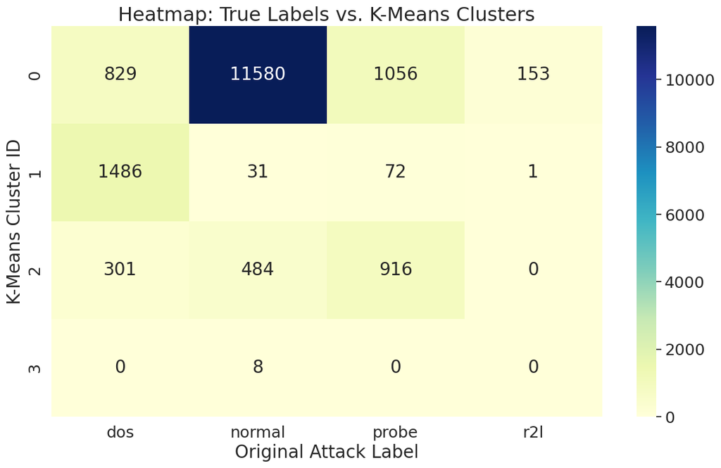

```python
mapping_table = analyze_cluster_distribution(y_original_train, kmeans_labels)
```

```python
import numpy as np
import pandas as pd
import matplotlib.pyplot as plt
import seaborn as sns
from sklearn.manifold import TSNE
import time

def perform_tsne_separate_plots(X, cluster_labels, true_labels, perplexities=[5, 30, 50],
                               comparison_file="tsne_comparison.png",
                               best_plot_file="tsne_best_result.png"):
    """
    Performs t-SNE analysis and saves the comparison plot and best plot as separate files.
    """
    tsne_results = {}

    # --- Task (i): Perplexity Comparison (3 parameters together) ---
    fig1, axes = plt.subplots(1, 3, figsize=(24, 7))

    for i, p in enumerate(perplexities[:3]):
        print(f"Computing t-SNE for perplexity {p}...")
        tsne = TSNE(
            n_components=2,
            perplexity=p,
            random_state=42,
            init='pca',
            learning_rate='auto',
            n_jobs=-1
        )
        X_embedded = tsne.fit_transform(X)
        tsne_results[p] = X_embedded

        # Plot labeled by Cluster ID
        sns.scatterplot(
            x=X_embedded[:, 0], y=X_embedded[:, 1],
            hue=cluster_labels, palette='tab10',
            alpha=0.5, ax=axes[i], legend='full'
        )
        axes[i].set_title(f'Cluster ID Distribution (Perplexity={p})')

    plt.tight_layout()
    plt.savefig(comparison_file, dpi=300,bbox_inches='tight', pad_inches=0.1) # Save comparison of 3 parameters
    print(f"Comparison plot saved as: {comparison_file}")
    plt.show()

    # --- Task (ii): Best Perplexity Visualization (Single separate plot) ---
    # Based on your data, Perplexity 30 usually offers a balanced view
    best_p = perplexities[1]
    best_embedding = tsne_results[best_p]

    plt.figure(figsize=(12, 8))
    sns.scatterplot(
        x=best_embedding[:, 0], y=best_embedding[:, 1],
        hue=true_labels, palette='viridis', alpha=0.6
    )
    plt.title(f'Ground Truth Attack Labels (Best Perplexity={best_p})')

    # Place legend outside to avoid overlapping with data points
    plt.legend(bbox_to_anchor=(1.05, 1), loc='upper left', title="Attack Types")
    plt.grid(True, linestyle='--', alpha=0.3)

    plt.tight_layout()
    plt.savefig(best_plot_file, dpi=300, bbox_inches='tight', pad_inches=0.1)# Save the best result separately
    print(f"Best result plot saved as: {best_plot_file}")
    plt.show()

    return tsne_results
```

```
Computing t-SNE for perplexity 5...
Computing t-SNE for perplexity 30...
Computing t-SNE for perplexity 50...
Comparison plot saved as: tsne_comparison.png
```

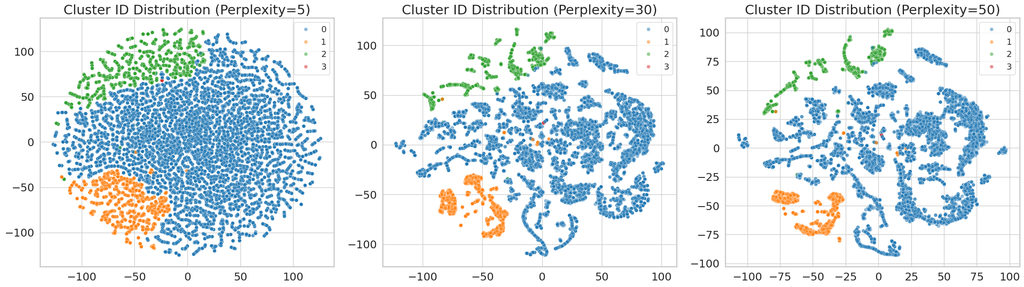

```
Best result plot saved as: tsne_best_result.png
```

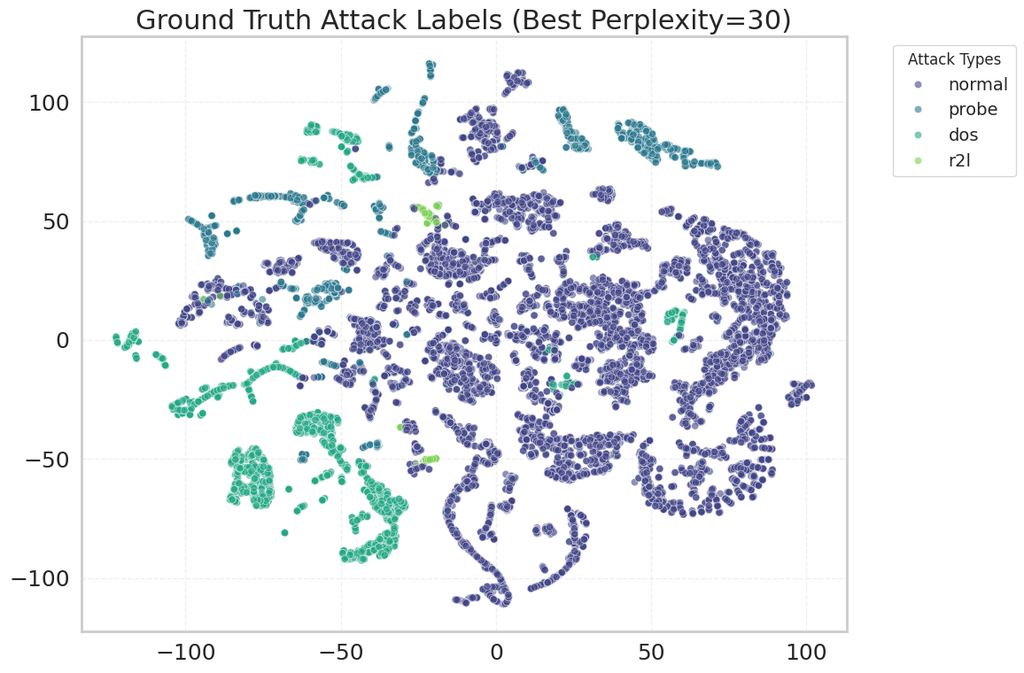

```python
final_tsne_maps = perform_tsne_separate_plots(X_train, kmeans_labels, y_original_train)
```

## DB-Scan anomalies are anomalies?: Finally, DB-Scan is a clustering algorithm designed to detect anomalous patterns that may represent anomalies. One way to estimate min_points is to evaluate the k-means result and look for the smallest cluster that consists only of normal data. This enables the definition of clusters with normal behavior.Set min_points according to this analysis. If you cannot find any pure cluster varying the number of cluster k, suggest and motivate your min_points choice. Next, use the elbow rule to determine the ϵ parameter based on the increasing distance between each point and its min_points neighbor.

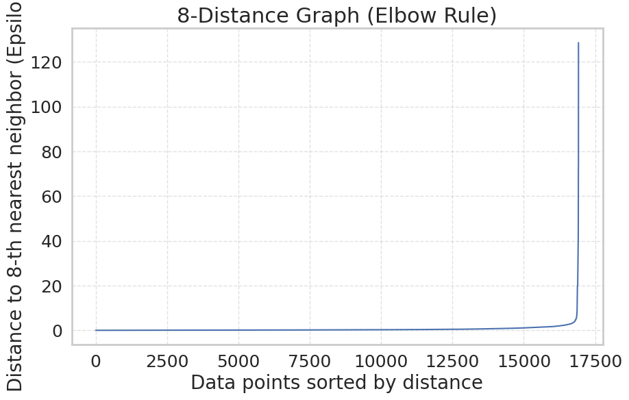

```python
import numpy as np
import matplotlib.pyplot as plt
from sklearn.neighbors import NearestNeighbors

# 1. Set k = min_points (8 as derived from K-means pure cluster)
k = 8

# 2. Initialize NearestNeighbors and fit to your normalized data
# We use Euclidean distance as discussed
neigh = NearestNeighbors(n_neighbors=k)
nbrs = neigh.fit(X_train)

# 3. Find the distances of each point to its k-th nearest neighbor
distances, indices = nbrs.kneighbors(X_train)

# 4. Sort the distances (the k-th column corresponds to the k-th neighbor)
# indices are 0 to k-1, so index 7 is the 8th neighbor
k_distances = np.sort(distances[:, k-1], axis=0)

# 5. Plot the K-distance Graph
plt.figure(figsize=(10, 6))
plt.plot(k_distances)
plt.title(f'{k}-Distance Graph (Elbow Rule)')
plt.xlabel('Data points sorted by distance')
plt.ylabel(f'Distance to {k}-th nearest neighbor (Epsilon)')
plt.grid(True, linestyle='--', alpha=0.6)
plt.show()
```

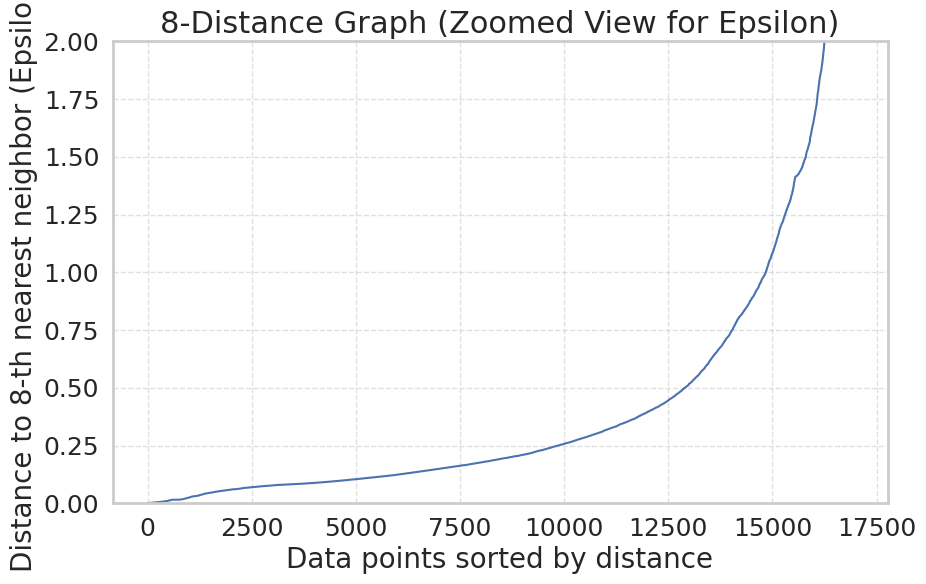

```python
import numpy as np
import matplotlib.pyplot as plt
from sklearn.neighbors import NearestNeighbors

# 1. Set k = min_points
min_samples = 8

# 2. Fit NearestNeighbors
neigh = NearestNeighbors(n_neighbors=min_samples)
nbrs = neigh.fit(X_train)

# 3. Find distances
distances, indices = nbrs.kneighbors(X_train)

# 4. Sort distances
k_distances = np.sort(distances[:, min_samples-1], axis=0)

# 5. Plotting with Zoom
plt.figure(figsize=(10, 6))
plt.plot(k_distances)

# --- ZOOMING SECTION ---
# Use ylim to zoom in on the 'elbow' distance range (e.g., 0 to 5)
plt.ylim(0, 2)

# Optional: Use xlim to zoom in on the last few points where the curve rises
# (e.g., from point 15000 to the end)
# plt.xlim(15000, len(k_distances))
# -----------------------

plt.title(f'{min_samples}-Distance Graph (Zoomed View for Epsilon)')
plt.xlabel('Data points sorted by distance')
plt.ylabel(f'Distance to {min_samples}-th nearest neighbor (Epsilon)')
plt.grid(True, linestyle='--', alpha=0.6)
plt.show()
```

```python
from sklearn.cluster import DBSCAN
import pandas as pd

# 1. Initialize DBSCAN with our estimated parameters
# eps=1.0: Derived from the zoomed elbow plot
# min_samples=8: Derived from the smallest pure normal K-Means cluster
dbscan = DBSCAN(eps=1.0, min_samples=8)

# 2. Fit and predict on your normalized training data
dbscan_labels = dbscan.fit_predict(X_train)

# 3. Basic result analysis
# set() removes duplicates; we subtract 1 if -1 (noise) is present
n_clusters = len(set(dbscan_labels)) - (1 if -1 in dbscan_labels else 0)
n_noise = list(dbscan_labels).count(-1)

print(f"Number of clusters found: {n_clusters}")
print(f"Number of anomalies detected (Noise): {n_noise}")

# 4. Create a comparison table with original ground truth labels
results_df = pd.DataFrame({
    'Original_Label': y_original_train,
    'DBSCAN_Cluster': dbscan_labels
})

# Cross-tabulation to see which attacks were caught as noise (-1)
comparison_table = pd.crosstab(results_df['DBSCAN_Cluster'], results_df['Original_Label'])
print("\n--- DBSCAN Cluster Distribution vs. Attack Labels ---")
print(comparison_table)
```

```
Number of clusters found: 96
Number of anomalies detected (Noise): 1581

--- DBSCAN Cluster Distribution vs. Attack Labels ---
Original_Label  dos  normal  probe  r2l
DBSCAN_Cluster
-1              146    1152    261   22
 0                0    1453      0    0
 1                0     449      0   87
 2                0       0    164    0
 3                0     239      0    0
...             ...     ...    ...  ...
 91               0       8      0    0
 92               0       8      0    0
 93               0       5      0    0
 94               0       9      0    0
 95               0      10      0    0

[97 rows x 4 columns]
```